# Final Project Preliminary EDA

November 15 2020

```r
##load packages
library(mosaic)
library(tidyverse)
library(dplyr)
library(ggplot2)
```

### Research Question:

What video games are the most popular based on critic reviews? This will be based on sale numbers and I also plan to break the popularity down by figuring out which games have the most popular critic score and cross referencing that with sales data to see if high critic score correlates with better sales.

I found the data sets on Kaggle and downloaded the .csv files from the Kaggle website.

### Meta Critic Games

Below, you can see a snippet of the data along with some summary statistics.

```r
head(metacritic_games)
```

|  | game | platform | developer | genre | number_players | rating | release_date | positive_critics | neutral_critics | negative_critics | positive_users | neutral_users | negative_users | metascore | user_score |
| --- | --- | --- | --- | --- | --- | --- | --- | --- | --- | --- | --- | --- | --- | --- | --- |
| 1 | Portal 2 | PC | Valve Software | Action |  | E10+ | Apr 18, 2011 | 51 | 1 | 0 | 1700 | 107 | 19 | 95 | 90 |
| 2 | The Elder Scrolls V: Skyrim | PC | Bethesda Game Studios | Role-Playing | No Online Multiplayer | M | Nov 10, 2011 | 32 | 0 | 0 | 1616 | 322 | 451 | 94 | 82 |
| 3 | The Legend of Zelda: Ocarina of Time 3D | 3DS | GREZZO | Miscellaneous | No Online Multiplayer | E10+ | Jun 19, 2011 | 84 | 1 | 0 | 283 | 20 | 5 | 94 | 90 |
| 4 | Batman: Arkham City | PC | Rocksteady Studios | Action Adventure |  | T | Nov 21, 2011 | 27 | 0 | 0 | 240 | 34 | 27 | 91 | 87 |
| 5 | Super Mario 3D Land | 3DS | Nintendo | Action | No Online Multiplayer | E | Nov 13, 2011 | 81 | 1 | 0 | 251 | 39 | 11 | 90 | 84 |
| 6 | Deus Ex: Human Revolution | PC | Nixxes Software | Action | No Online Multiplayer | M | Aug 23, 2011 | 52 | 0 | 0 | 520 | 112 | 78 | 90 | 85 |

```r
summary(metacritic_games)
```

```
     game             platform
 Length:5699        Length:5699
 Class :character   Class :character
 Mode  :character   Mode  :character



  developer            genre
 Length:5699        Length:5699
 Class :character   Class :character
 Mode  :character   Mode  :character



 number_players        rating
 Length:5699        Length:5699
 Class :character   Class :character
 Mode  :character   Mode  :character



 release_date       positive_critics
 Length:5699        Min.   :  0.00
 Class :character   1st Qu.:  3.00
 Mode  :character   Median :  8.00
                    Mean   : 13.35
                    3rd Qu.: 17.00
                    Max.   :118.00
 neutral_critics  negative_critics
 Min.   : 0.000   Min.   : 0.000
 1st Qu.: 3.000   1st Qu.: 0.000
 Median : 6.000   Median : 0.000
 Mean   : 7.959   Mean   : 1.146
 3rd Qu.:10.000   3rd Qu.: 1.000
 Max.   :65.000   Max.   :51.000
 positive_users    neutral_users
 Min.   :   0.00   Min.   :  0.000
 1st Qu.:   2.00   1st Qu.:  1.000
 Median :   5.00   Median :  2.000
 Mean   :  28.75   Mean   :  8.637
 3rd Qu.:  17.00   3rd Qu.:  6.000
 Max.   :2762.00   Max.   :506.000
 negative_users      metascore
 Min.   :   0.00   Min.   :11.00
 1st Qu.:   0.00   1st Qu.:66.00
 Median :   1.00   Median :73.00
 Mean   :  14.37   Mean   :71.86
 3rd Qu.:   5.00   3rd Qu.:80.00
 Max.   :2998.00   Max.   :97.00
   user_score
 Min.   : 1.00
 1st Qu.:61.00
 Median :70.00
 Mean   :67.14
 3rd Qu.:76.00
 Max.   :94.00
```

This data set does not have much information on how it was collected and maintained, however it can be assumed she scraped the data from a meta critic score website.

A case in this dataset describes a video game and its respective critic and user score, whether positive, neutral, or negative. It also includes the platform, genre, and rating.

I plan to use the game, platform, genre, positive_critics, and negative_critics in conjunction with the other dataset to conclude popular video games and their ratings.

```r
nrow(metacritic_games)
```

```
[1] 5699
```

The dataset has a lot of rows for exploration at 5,699 rows in total.

### Video Game Sales

The second dataset I chose is the Video Game Sales data set. This dataset was collected by Gregory Smith who is a data engineer at Petzl America. This is the second version of the data and has not been updated for 4 years. It can be found at: https://www.kaggle.com/gregorut/videogamesales. I plan to use this dataset as a supplementary data source for the meta critic games dataset by using it to analyze how well rated games sold in both the North American and Global Markets. Below, you can see a snippet of the data and the columns included in the data set.

```r
head(vgsales)
```

|  | Rank | Name | Platform | Year | Genre | Publisher | NA_Sales | EU_Sales | JP_Sales | Other_Sales | Global_Sales |
| --- | --- | --- | --- | --- | --- | --- | --- | --- | --- | --- | --- |
| 1 | 1 | Wii Sports | Wii | 2006 | Sports | Nintendo | 41.49 | 29.02 | 3.77 | 8.46 | 82.74 |
| 2 | 2 | Super Mario Bros. | NES | 1985 | Platform | Nintendo | 29.08 | 3.58 | 6.81 | 0.77 | 40.24 |
| 3 | 3 | Mario Kart Wii | Wii | 2008 | Racing | Nintendo | 15.85 | 12.88 | 3.79 | 3.31 | 35.82 |
| 4 | 4 | Wii Sports Resort | Wii | 2009 | Sports | Nintendo | 15.75 | 11.01 | 3.28 | 2.96 | 33.00 |
| 5 | 5 | Pokemon Red/Pokemon Blue | GB | 1996 | Role-Playing | Nintendo | 11.27 | 8.89 | 10.22 | 1.00 | 31.37 |
| 6 | 6 | Tetris | GB | 1989 | Puzzle | Nintendo | 23.20 | 2.26 | 4.22 | 0.58 | 30.26 |

```r
summary(vgsales)
```

```
      Rank           Name
 Min.   :    1   Length:16598
 1st Qu.: 4151   Class :character
 Median : 8300   Mode  :character
 Mean   : 8301
 3rd Qu.:12450
 Max.   :16600
   Platform             Year
 Length:16598       Length:16598
 Class :character   Class :character
 Mode  :character   Mode  :character



    Genre            Publisher
 Length:16598       Length:16598
 Class :character   Class :character
 Mode  :character   Mode  :character



    NA_Sales          EU_Sales
 Min.   : 0.0000   Min.   : 0.0000
 1st Qu.: 0.0000   1st Qu.: 0.0000
 Median : 0.0800   Median : 0.0200
 Mean   : 0.2647   Mean   : 0.1467
 3rd Qu.: 0.2400   3rd Qu.: 0.1100
 Max.   :41.4900   Max.   :29.0200
    JP_Sales         Other_Sales
 Min.   : 0.00000   Min.   : 0.00000
 1st Qu.: 0.00000   1st Qu.: 0.00000
 Median : 0.00000   Median : 0.01000
 Mean   : 0.07778   Mean   : 0.04806
 3rd Qu.: 0.04000   3rd Qu.: 0.04000
 Max.   :10.22000   Max.   :10.57000
  Global_Sales
 Min.   : 0.0100
 1st Qu.: 0.0600
 Median : 0.1700
 Mean   : 0.5374
 3rd Qu.: 0.4700
 Max.   :82.7400
```

This dataset was also available in a .csv format from Kaggle which I was able to download and import into RStudio.

A case in this dataset is the same as the last where one case represents video game sales for a particular video game in the year it was released.

I plan to use the Name, Platform, Genre, Year, and NA_Sales columns in my data exploration. I plan to use these in conjunction with the Meta Critic Games data set columns.

```r
nrow(vgsales)
```

```
[1] 16598
```

### Informative Plots

With the summary statistics above, I am planning to gauge popularity for the most popular video games by using both critic score and sales.

```r
highest_rank <- which.max(metacritic_games$positive_critics)
highest_rank
```

```
[1] 4513
```

```r
pos <- metacritic_games %>% filter(positive_critics > 100)
pos
```

| game | platform | developer | genre | number_players | rating | release_date | positive_critics | neutral_critics | negative_critics | positive_users | neutral_users | negative_users | metascore | user_score |
| --- | --- | --- | --- | --- | --- | --- | --- | --- | --- | --- | --- | --- | --- | --- |
| Uncharted 4: A Thief's End | PS4 | Naughty Dog | General | Up to 10 | T | May 10, 2016 | 111 | 1 | 1 | 1533 | 148 | 68 | 93 | 84 |
| The Legend of Zelda: Breath of the Wild | Switch | Nintendo | Action Adventure | No Online Multiplayer | E10+ | Mar 3, 2017 | 106 | 3 | 0 | 2762 | 241 | 135 | 97 | 85 |
| Super Mario Odyssey | Switch | Nintendo | Action | No Online Multiplayer | E10+ | Oct 27, 2017 | 113 | 0 | 0 | 977 | 62 | 30 | 97 | 90 |
| Horizon Zero Dawn | PS4 | Guerrilla | Role-Playing | No Online Multiplayer | T | Feb 28, 2017 | 110 | 5 | 0 | 1168 | 117 | 105 | 89 | 83 |
| God of War | PS4 | SCE Santa Monica | Action Adventure | No Online Multiplayer | M | Apr 20, 2018 | 118 | 0 | 0 | 2488 | 109 | 109 | 94 | 91 |
| Marvel's Spider-Man | PS4 | Insomniac Games | Action Adventure | No Online Multiplayer | T | Sep 7, 2018 | 110 | 6 | 0 | 795 | 66 | 44 | 87 | 87 |

By filtering for games that were had more than 100 positiv critic scores, you are left with the 6 most popular games rated by critics.

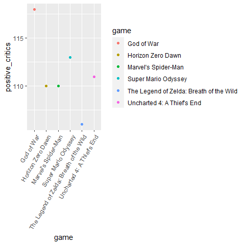

```r
pos %>% ggplot(aes(x = game,y=positive_critics)) + geom_point(aes(color=game)) + theme(axis.text.x = element_text(angle = 60, vjust = 1, hjust=1))
```

Although this graph is a bit crowded in Rstudio, seeing it as a full graph you can see a visualization of the 6 most popular games according to critics, with God of War being the most popular.

With this information, we can see how well God of War did in sales:

```r
vgsales.12.4.2019 %>% filter(Name == "God of War")
```

| Rank | Name | basename | Genre | ESRB_Rating | Platform | Publisher | Developer | VGChartz_Score | Critic_Score | User_Score | Total_Shipped | Global_Sales | NA_Sales | PAL_Sales | JP_Sales | Other_Sales | Year | Last_Update | url | status | Vgchartzscore | img_url |
| --- | --- | --- | --- | --- | --- | --- | --- | --- | --- | --- | --- | --- | --- | --- | --- | --- | --- | --- | --- | --- | --- | --- |
| 289 | God of War | god-of-war | Action | M | PS2 | Sony Computer Entertainment | SCEA Santa Monica Studio | NA | 9.3 | NA | 4.62 | NA | NA | NA | NA | NA | 2005 |  | http://www.vgchartz.com/game/869/god-of-war/?region=All | 1 | NA | /games/boxart/full_5633331AmericaFrontccc.jpg |

```r
metacritic_games %>% filter(game == "The Elder Scrolls V: Skyrim")
```

| game | platform | developer | genre | number_players | rating | release_date | positive_critics | neutral_critics | negative_critics | positive_users | neutral_users | negative_users | metascore | user_score |
| --- | --- | --- | --- | --- | --- | --- | --- | --- | --- | --- | --- | --- | --- | --- |
| The Elder Scrolls V: Skyrim | PC | Bethesda Game Studios | Role-Playing | No Online Multiplayer | M | Nov 10, 2011 | 32 | 0 | 0 | 1616 | 322 | 451 | 94 | 82 |
| The Elder Scrolls V: Skyrim | Switch | Bethesda Game Studios, Iron Galaxy Studios | Role-Playing | No Online Multiplayer | M | Nov 17, 2017 | 62 | 1 | 0 | 49 | 5 | 9 | 84 | 82 |

```r
vgsales %>% filter(Name == "The Elder Scrolls V: Skyrim")
```

| Rank | Name | Platform | Year | Genre | Publisher | NA_Sales | EU_Sales | JP_Sales | Other_Sales | Global_Sales |
| --- | --- | --- | --- | --- | --- | --- | --- | --- | --- | --- |
| 76 | The Elder Scrolls V: Skyrim | X360 | 2011 | Role-Playing | Bethesda Softworks | 5.03 | 2.86 | 0.10 | 0.85 | 8.84 |
| 127 | The Elder Scrolls V: Skyrim | PS3 | 2011 | Role-Playing | Bethesda Softworks | 2.55 | 2.71 | 0.25 | 1.05 | 6.56 |
| 311 | The Elder Scrolls V: Skyrim | PC | 2011 | Role-Playing | Bethesda Softworks | 1.15 | 2.09 | 0.00 | 0.64 | 3.88 |

As you can see, The Elder Scrolls V: Skyrim has been released 5 times (which is so annoying), and has lots of different sales data for different platforms. However, you can see it sells very well and has very good critic scores.